# Introdução à Macroeconomia

Claudia Tanaka

Atualizado em 24/09/2024

# Setup

Pacotes e ambiente de programação:

**datasets**

```r
suppressMessages(

df.pib <-
  rbind(
    # Tabela 6612: Valores encadeados a preços de 1995
    sidrar::get_sidra(
      api="/t/6612/n1/all/v/all/p/all/c11255/90707/d/v9318%202"
    ),
    # Tabela 1846: Valores a preços correntes (Milhões de Reais)
    sidrar::get_sidra(
      api="/t/1846/n1/all/v/all/p/all/c11255/90707/d/v585%200"
    ),
    # Tabela 1620: Série encadeada do índice de volume trimestral
    # (Base: média 1995 = 100)
    sidrar::get_sidra(
      api="/t/1620/n1/all/v/all/p/all/c11255/90707/d/v583%204"
    ),
    # Tabela 1621: Série encadeada do índice de volume trimestral com ajuste sazonal
    # (Base: média 1995 = 100)
    sidrar::get_sidra(
      api="/t/1621/n1/all/v/all/p/all/c11255/90707/d/v584%204"
    )
  )  |>
  janitor::clean_names() |>
  select(id_trimestre=trimestre_codigo, variavel, valor) |>
  mutate(
    id_trimestre = lubridate::yq(id_trimestre) |> yearquarter(),
    .before=everything()
  ) |>
  as_tsibble(index = id_trimestre, key = c(variavel)) |>
  fill_gaps() |>
  mutate(
    variavel = case_match(
      variavel,
      "Série encadeada do índice de volume trimestral (Base: média 1995 = 100)"
      ~ "num_indice",

      "Série encadeada do índice de volume trimestral com ajuste sazonal (Base: média 1995 = 100)"
      ~ "num_indice_sa",

      "Valores a preços correntes" ~ "pib_nominal",

      "Valores encadeados a preços de 1995" ~ "pib_real95",

      .default = NA
    )
  ) |>
  pivot_wider(names_from=variavel, values_from=valor) |>
  mutate(
    pib_deflator = pib_nominal / pib_real95 * 100,

    # Variação anual acumulada em 12 meses (4 trimestres)
    var_yoy_12m_preco = (
      zoo::rollsumr(pib_deflator, k=4, fill=NA) / (
        zoo::rollsumr(pib_deflator, k=8, fill=NA) -
          zoo::rollsumr(pib_deflator, k=4, fill=NA)
      ) - 1
    ) * 100,

    # Variação trimestre contra trimestre imediatamente anterior (t contra t-1)
    var_qoq_qtd = (num_indice_sa / lag(x = num_indice_sa, n = 1) - 1) * 100,

    # Variação trimestre contra mesmo trimestre do ano anterior (t contra t-4)
    var_yoy_3m_qtd = (num_indice / lag(x = num_indice, n = 4) - 1) * 100,

    # Variação anual acumulada em 12 meses (4 trimestres)
    var_yoy_12m_qtd = (
      zoo::rollsumr(num_indice, k=4, fill=NA) / (
        zoo::rollsumr(num_indice, k=8, fill=NA) -
          zoo::rollsumr(num_indice, k=4, fill=NA)
      ) - 1
    ) * 100
  ) |>
  arrange(id_trimestre) |>
  select(id_trimestre,
         pib_nominal,          # preços correntes - mudanças de qtd e preço
         pib_real95,           # preços constantes - mudanças de qtd
         pib_deflator,         # índice de preços - mudanças de preço
         var_yoy_12m_preco,  # variação anual dos preços
         num_indice,           # índice de volume - mudanças de qtd
         var_yoy_3m_qtd, var_yoy_12m_qtd, # variação anual das quantidades
         num_indice_sa,        # índice de volume com ajuste sazonal
         var_qoq_qtd) |>
  mutate(
    pib_real_atual = pib_nominal * (
      num_indice[id_trimestre==max(id_trimestre)] / num_indice
    ),
    .after = pib_real95
  )

)
```

```r
# PIB (e componentes do PIB)
suppressMessages(

df.pib_componentes <-
  rbind(
    # Tabela 1620 - Série encadeada do índice de volume trimestral
    # (Base: média 1995 = 100)
    sidrar::get_sidra(
      api = paste0(
        "/t/1620/n1/all/v/all/p/all/c11255/90687,90691,90696,90707,",
        "93404,93405,93406,93407,93408/d/v583%202"
      )
    ),
    # Tabela 1846 - Valores a preços correntes (Milhões de Reais)
    sidrar::get_sidra(
      api = paste0(
        "/t/1846/n1/all/v/all/p/all/c11255/90687,90691,90696,",
        "90707,93404,93405,93406,93407,93408/d/v585%200"
      )
    )
  ) |>
  janitor::clean_names() |>
  select(
    id_trimestre = trimestre_codigo,
    variavel,
    componente = setores_e_subsetores,
    valor
  ) |>
  mutate(
    id_trimestre = yq(id_trimestre) |> yearquarter(),

    variavel = recode(
      variavel,
      "Valores a preços correntes" = "pib_nominal",
      "Série encadeada do índice de volume trimestral (Base: média 1995 = 100)" = "num_indice"
    ),

    componente = stringr::str_remove_all(
      componente,
      " - total| a preços de mercado| \\(-\\)| de bens e serviços"
    ) |>
      recode(
        "Despesa de consumo das famílias"             = "Cons. das famílias",
        "Despesa de consumo da administração pública" = "Desp. do governo",
        "Formação bruta de capital fixo"              = "FBCF"
      ) |>
      factor(levels=c("Agropecuária",
                      "Indústria",
                      "Serviços",
                      "PIB",
                      "Cons. das famílias",
                      "Desp. do governo",
                      "FBCF",
                      "Exportação",
                      "Importação")),

    otica = case_match(
      componente,
      c("Agropecuária","Indústria","Serviços") ~ "Oferta",
      c("Cons. das famílias",
        "Desp. do governo",
        "FBCF",
        "Exportação",
        "Importação") ~ "Demanda",
      .default = componente
    )
  ) |>
  pivot_wider(names_from=variavel, values_from=valor) |>
  as_tsibble(index = id_trimestre, key = c(componente, otica)) |>
  mutate(
    # PIB nominal acumulado em 12 meses (4 trimestres)
    pib_nominal_12m = zoo::rollsumr(pib_nominal, k=4, fill=NA),

    # Variação acumulada em 12 meses (4 trimestres)
    var_yoy_12m_qtd = (
      zoo::rollsumr(num_indice, k=4, fill=NA) / (
        zoo::rollsumr(num_indice, k=8, fill=NA) -
          zoo::rollsumr(num_indice, k=4, fill=NA)
      ) - 1
    ) * 100,
    .by = componente
  )

)
```

```r
suppressMessages(

df.ipca <-
  sidrar::get_sidra(api="/t/1737/n1/all/v/2266/p/all/d/v2266%2013") |>
  janitor::clean_names() |>
  select(mes_codigo, variavel, valor, unidade_de_medida) |>
  mutate(id_mes = yearmonth(
    paste0(
      substr(mes_codigo, 1, 4), "-",
      substr(mes_codigo, 5, 6)
    )),
    .before=everything()
  ) |>
  select(-mes_codigo) |>
  as_tsibble(index = id_mes, key = c(variavel, unidade_de_medida)) |>
  fill_gaps() |>
  mutate(
    variavel = case_match(
      variavel,
      "IPCA - Número-índice (base: dezembro de 1993 = 100)" ~ "num_indice",
      .default = NA
    )
  ) |>
  pivot_wider(names_from=variavel, values_from=valor) |>
  mutate(
    # Variação mês contra mês imediatamente anterior (t contra t-1)
    var_mensal = (num_indice / lag(x = num_indice, n = 1) - 1) * 100,

    # Variação acumulada em 12 meses
    var_anual = (num_indice / lag(x = num_indice, n = 12) - 1) * 100
  )

)
```

```r
suppressMessages(

df.pnad <-
  sidrar::get_sidra(api="/t/4099/n1/all/v/4099/p/all/d/v4099%201") |>
  janitor::clean_names() |>
  select(trimestre_codigo, variavel, valor, unidade_de_medida) |>
  mutate(id_trimestre = lubridate::yq(trimestre_codigo) |> yearquarter(),
    .before=everything()
  ) |>
  select(-trimestre_codigo, -unidade_de_medida) |>
  as_tsibble(index = id_trimestre, key = c(variavel)) |>
  fill_gaps() |>
  mutate(
    variavel = case_match(
      variavel,
      "Taxa de desocupação, na semana de referência, das pessoas de 14 anos ou mais de idade"
      ~ "tx_desemprego",
      .default = NA
    )
  ) |>
  pivot_wider(names_from=variavel, values_from=valor)

)
```

```r
df.sal_min <-
  ipeadatar::ipeadata("MTE12_SALMIN12") |>
  select(date, salario_minimo=value) |>
  mutate(id_mes = yearmonth(date), .before=everything()) |>
  select(-date) |>
  as_tsibble(index = id_mes) |>
  fill_gaps()


suppressMessages(

df.inpc <-
  sidrar::get_sidra(api="/t/1736/n1/all/v/2289/p/all/d/v2289%2013") |>
  janitor::clean_names() |>
  select(mes_codigo, variavel, valor, unidade_de_medida) |>
  mutate(id_mes = yearmonth(
    paste0(
      substr(mes_codigo, 1, 4), "-",
      substr(mes_codigo, 5, 6)
    )),
    .before=everything()
  ) |>
  select(-mes_codigo) |>
  as_tsibble(index = id_mes, key = c(variavel, unidade_de_medida)) |>
  fill_gaps()

)
```

# 1 Introdução à Macroeconomia

A macroeconomia é um ramo da ciência econômica que estuda o comportamento de uma economia como um todo. Em contraste, a microeconomia se preocupa em como os indivíduos e firmas tomam decisões. Por exemplo:

- A decisão de um trabalhador em fazer horas extras não é um problema macroeconômico;
- A taxa de inflação observada em uma economia é um problema macroeconômico.

Dessa forma, os macroeconomistas preocupam-se em analisar indicadores agregados como PIB, taxa de desemprego e índices de preços para entender como toda a economia funciona.

Em termos didáticos, você também pode pensar na distinção entre macro e micro com o uso de uma analogia:

- A macroeconomia procura olhar apenas para a floresta como um todo, sem se preocupar com as árvores;
- A microeconomia se preocupa com as árvores individualmente e se esquece da floresta.

No entanto, a teoria econômica moderna combina conceitos micro e macro, de modo que a macroeconomia atual é microfundamentada. Dessa forma, muitos tópicos interessantes podem surgir e são estudados na macroeconomia, como:

- Por que o custo de vida continua subindo?
- Por que milhões de pessoas estão desempregadas, mesmo quando a economia está crescendo?
- O que causa recessões? E os ciclos econômicos?
- Aumentar a oferta monetária pode gerar mais crescimento?
- Por que tantos países são pobres? Quais políticas poderiam ajudá-los a sair da pobreza?
- O que determina o crescimento econômico de longo prazo da economia?
- A taxa de câmbio deve ser mantida em um nível fixo?
- Pode-se trocar um aumento da inflação por uma diminuição do desemprego?

De forma a endereçar questões como essas os economistas costumam formular modelos, que podem ser entendidos como representações simplificadas do mundo real, usados como base para explicar relações ou realizar previsões.

**Por exemplo**: um mapa é, em essência, um modelo para nos locomovermos de um ponto A a um ponto B.

## 1.1 Conceitos fundamentais

- **Ceteris paribus**: uma expressão do latim que significa “todo o mais é constante”, ou seja, nada muda, exceto o fator ou fatores que estão sendo estudados;
- **Variável endógena**: também chamada de dependente, é a variável cujos valores são determinados no modelo;
- **Variável exógena**: também chamada de independente, é a variável cujos valores são determinados fora do modelo, ou seja, o modelo toma seus valores e comportamento como dados;
- **Preços flexíveis**: uma suposição de que os preços são flexíveis, ou seja, se ajustam para igualar oferta e demanda. Por exemplo: com o advento da pandemia da Covid-19 os preços de alimentação e bebidas aumentaram expressivamente no Brasil;
- **Preços rígidos**: no curto prazo, muitos preços são rígidos, ou seja, se ajustam lentamente em resposta a mudanças na oferta ou na demanda. Por exemplo: muitos contratos de trabalho fixam o salário nominal por 1 ano ou mais.
- **Agregados macroeconômicos**: aquelas variáveis que representam de forma agregada toda a economia de um país, sintetizando informações para a análise e comparações. Por exemplo: o PIB é a soma de todos os bens e serviços finais produzidos por um país em determinado período de tempo.
- **Fluxo**: magnitude econômica medida dentro de um intervalo de tempo. Por exemplo: PIB (taxa trimestral), salário (mensal), os pagamentos (periódicos) de uma dívida parcelada;
- **Estoque**: é uma magnitude medida em um determinado ponto específico no tempo. Por exemplo: saldo do CAGED no ano, dívida externa do país, população do país.

## 1.2 Metas de política econômica

Os políticos devem ser aconselhados sobre como influenciar o comportamenteo da economia de modo que metas especificadas possam ser cumpridas de forma obimizada. Conforme Blanchard (2017), as metas são, geralmente, constituícas pelo tripé de **crescimento econômico**, **preços estáveis** e **baixo desemprego**

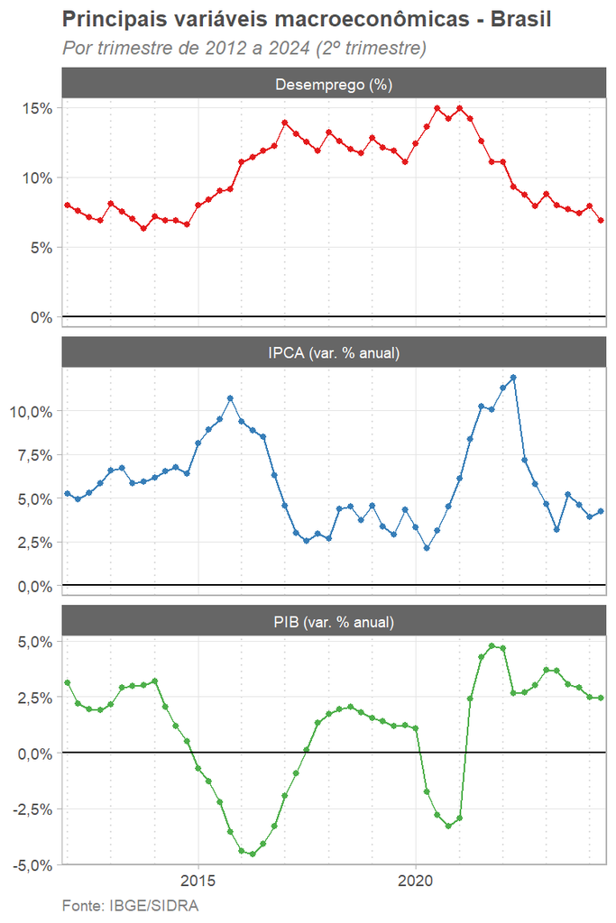

# 2 Deflacionando dados

Algumas pessoas ainda devem se lembrar de quando era possível “fazer o rancho”, as compras do mês, com apenas cem reais no bolso, mas já faz bastante tempo que uma simples ida ao supermercado é deveras custosa. O carro popular que podia ser adquirido por menos de R$ 30 mil nos anos 1990 é facilmente vendido por não menos de R$ 50 mil hoje. Ou seja, com uma nota de R$ 100 não se compra a mesma quantidade de bens hoje do que era possível há 20 anos e isso constitui um problema econômico básico, motivo pelo qual devemos deflacionar valores monetários para poder compará-los no tempo.

Sendo assim, se queremos ter uma visão realística quando analisando uma série de preços, devemos transformar os valores nominais para valores deflacionados, ou reais, contabilizando o efeito inflacionário do período. Apesar de ser um procedimento padrão, costumam haver alguns equívocos, de modo que iremos esclarecer alguns pontos e explorar abordagens da técnica usando as linguagens R e Python.

Em resumo, para transformar uma série de preços para valores reais, são necessárias duas coisas:

- Os **dados nominais**;
- Um **índice de preços adequado**.

A série de **dados nominais** pode ser qualquer uma que mede algo em **valores correntes (R$)**, como por exemplo a série do salário mínimo, disponibilizada pelo **IPEADATA**.

Já o **índice de preços** adequado pode vir de diversas fontes, os mais conhecidos no Brasil são o Índice Nacional de Preços ao Consumidor Amplo (IPCA), o Índice Nacional de Preços ao Consumidor (INPC) e o Índice Geral de Preços - Mercado (IGP-M), este divulgado pela **FGV** e aqueles pelo **IBGE**. O que esses índices fazem é medir o preço de uma cesta de produtos em um dado período de tempo, geralmente um mês cheio, em relação a um outro período de tempo base.

Com esses dois dados em mãos, basta aplicar a **fórmula de deflacionamento** a seguir:

$$Vr_{i:j} = (\frac{I_{j}}{I_{i}}) \times V_{i}$$
onde:
$Vr_{i:j}$ é o valor real, ou deflacionado, no período $i$ na data-base $j$
$I_{j}$ é o índice de preços fixado na data-base $j$
$I_{i}$ é o índice de preços no período $i$
$V_{i}$ é o valor ou preço nominal no período $i$

Com esta fórmula é possível obter o valor deflacionado a partir da multiplicação do valor nominal em um dado período pela razão entre o índice de preços na data-base de referência em relação ao índice no período de análise/interesse.

```r
df0 <-
  inner_join(
    df.sal_min,
    df.inpc |> select(id_mes, idx_inpc=valor),
    join_by(id_mes)
  ) |>
  fill_gaps()
```

Com base na fórmula de deflacionamento e nos dados, para obter o salário mínimo real precisamos apenas **definir qual será a data-base e, então, aplicar a fórmula** para obter o valor real para qualquer período de tempo que você estiver interessado.

**Por exemplo**:

Se quiséssemos saber o salário mínimo **real** de julho de 2021 na data-base de dezembro de 2021, ou seja, o salário em 07/2021 a preços de 12/2021, a expressão seria

$$\begin{align*}
Vr_{(i \ : \ j)} & = (\frac{I_{j}}{I_{i}}) \times V_{i} \\
Vr_{(07/21 \ : \ 12/21)} & = (\frac{6330.59_{(12/21)}}{6034.73_{(07/21)}}) \times 1100_{(07/21)} = 1153.93
\end{align*}$$

```r
df0 <-
  df0 |>
  mutate(salario_minimo_real = (max(idx_inpc) / idx_inpc) * salario_minimo) |>
  filter(year(id_mes)>=1980)
```

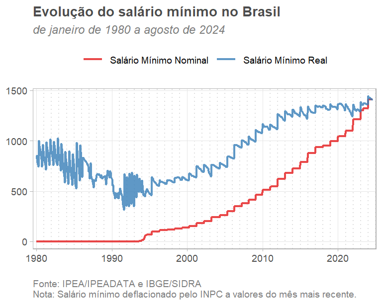

# 3 Contas Nacionais Trimestrais

O **Sistema de Contas Nacionais (SCN)** é o conjunto padronizado de recomendações internacionalmente acordadas sobre como compilar as medidas de atividade econômica, de acordo com rígidas convenções contábeis baseadas em princípios econômicos. Saiba mais em: https://unstats.un.org/unsd/nationalaccount/sna.asp

No Brasil o responsável por compilar e divulgar essas estatísticas é o **IBGE** através do [**Sistema de Contas Nacionais Trimestrais (SCNT)**](https://www.ibge.gov.br/estatisticas/economicas/industria/9300-contas-nacionais-trimestrais.html?=&t=resultados). Nesse sistema são disponibilizados os valores correntes e índice de volume (1995=100) para:

- Produto Interno Bruto (PIB) a preços de mercado;
- Impostos sobre produtos;
- Valor adicionado a preços básicos;
- Consumo pessoal;
- Consumo do governo;
- Formação bruta de capital fixo (FBCF);
- Variação de estoques
- Exportações e importações de bens e serviços.

Saiba mais em: https://www.ibge.gov.br/estatisticas/economicas/industria/9300-contas-nacionais-trimestrais.html?=&t=o-que-e

## 3.1 PIB

- **O que é o PIB?**

O PIB é a soma de todos os bens e serviços **finais** produzidos por um país, estado ou cidade, geralmente em um ano. Todos os países calculam o seu PIB nas suas respectivas moedas.

- **Por que bens e serviços finais?**

O PIB mede apenas os bens e serviços finais para evitar **dupla contagem**. Por exemplo, se um país produz R$ 100 de trigo, R$ 200 de farinha de trigo e R$ 300 de pão, seu PIB será de R$ 300, pois os valores da farinha e do trigo já estão embutidos no valor do pão.

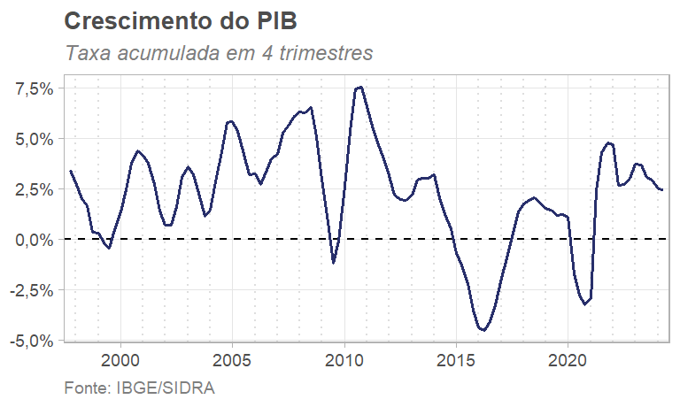

Em resumo, o PIB é um indicador que ajuda a compreender a economia como um todo, mas não expressa importantes fatores, como distribuição de renda, qualidade de vida, educação e saúde.

## 3.2 Óticas do PIB

O PIB pode ser expresso por **três óticas**:

- **Oferta** (produto): PIB é igual ao valor bruto da produção, a preços básicos, menos o consumo intermediário, a preços de consumidor, mais os impostos, líquidos de subsídios, sobre produtos;
- **Demanda** (despesa): PIB é igual a despesa de consumo das famílias, mais o consumo do governo, mais o consumo das instituições sem fins de lucro a serviço das famílias (consumo final), mais a formação bruta de capital fixo, mais a variação de estoques, mais as exportações de bens e serviços, menos as importações de bens e serviços;
- **Renda**: PIB é igual à remuneração dos empregados, mais o total dos impostos, líquidos de subsídios, sobre a produção e a importação, mais o rendimento misto bruto, mais o excedente operacional bruto.

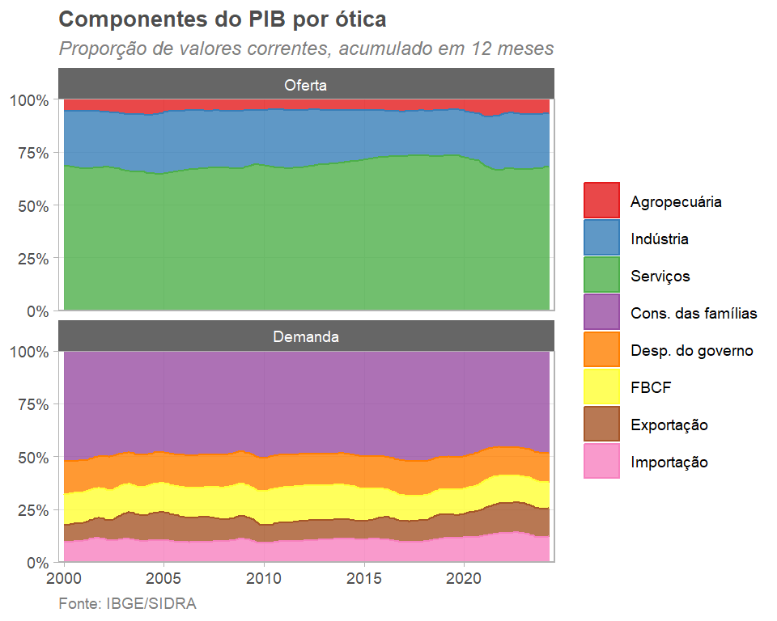

```r
df.pib_componentes |>
  filter(year(id_trimestre) >= 2000 & otica != "PIB") |>
  mutate(otica = factor(otica, levels=c("Oferta", "PIB", "Demanda"))) |>
  mutate(pct = pib_nominal_12m/sum(pib_nominal_12m),
         .by=c(id_trimestre, otica)) |>
  ggplot(aes(x=as_date(id_trimestre), y=pct,
             color=componente, fill=componente)) +
  facet_wrap(~otica, ncol=1) +
  geom_area(alpha=.8) +
  scale_y_continuous(labels=scales::label_percent(),
                     expand=expansion(mult=c(0,NA))) +
  scale_x_date(expand=expansion(mult=c(0.01,0.01))) +
  scale_fill_brewer(palette="Set1") +
  scale_color_brewer(palette="Set1") +
  labs(
    title = "Componentes do PIB por ótica",
    subtitle = "Proporção de valores correntes, acumulado em 12 meses",
    x = NULL, y = NULL,
    caption = "Fonte: IBGE/SIDRA"
  )
```

#### 3.2.0.1 Porque os totais são diferentes em cada ótica?

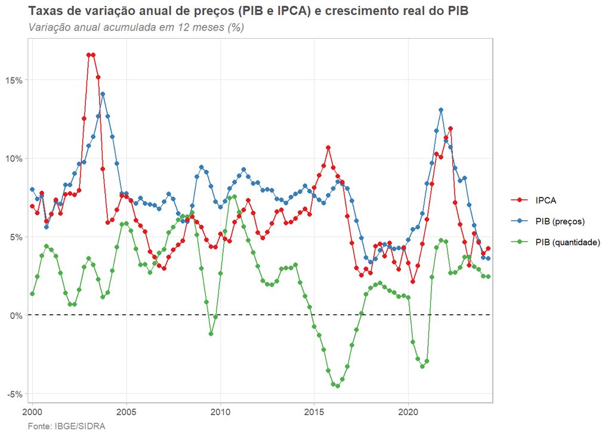

```r
inner_join(
  df.pib |>
  select(
    id_trimestre,
    "PIB (quantidade)" = var_yoy_12m_qtd,
    "PIB (preços)" = var_yoy_12m_preco,
  ),
  df.ipca |>
    select(id_mes, var_anual) |>
    filter(month(id_mes) %in% c(3,6,9,12)) |>
    mutate(id_trimestre = yearquarter(id_mes)) |>
    as_tsibble(index = id_trimestre) |>
    select(id_trimestre, "IPCA" = var_anual),
  join_by(id_trimestre)
) |>
  pivot_longer(-1, values_drop_na=T) |>
  filter(year(id_trimestre)>=2000) |>
  # filter(quarter(id_trimestre)==4) |>
  # mutate(ano = year(id_trimestre)) |>
  ggplot(aes(x=as_date(id_trimestre), y=value, color=name, group=name)) +
  geom_line() + geom_point() +
  geom_hline(yintercept=0, linetype="dashed") +
  scale_x_date(expand=expansion(mult=c(.01,.01))) +
  scale_y_continuous(
    labels=scales::number_format(big.mark=".", decimal.mark=",",
                                 suffix="%")
  ) +
  scale_color_brewer(palette="Set1") +
  labs(
    title = "Taxas de variação anual de preços (PIB e IPCA) e crescimento real do PIB",
    subtitle = "Variação anual acumulada em 12 meses (%)",
    x = NULL, y = NULL,
    caption = "Fonte: IBGE/SIDRA"
  )
```

# Referências

Blanchard, O. (2017). *Macroeconomics.* Pearson Education Limited.

IBGE - Instituto Brasileiro de Geografia e Estatística. *Contas nacionais trimestrais*: ano de referência 2010. Rio de Janeiro: IBGE, 2016. Disponível em: https://biblioteca.ibge.gov.br/visualizacao/livros/liv96834.pdf. Acesso em: 07 jun. 2021.

Mankiw, N. G. (2018). *Macroeconomics.* Macmillan Higher Education.